# Detecting hidden heterogeneity in single cell RNA-Seq data

Donghyung Lee

2017-08-15

The iasva package can be used to detect hidden heterogenity within bulk or single cell sequencing data. To illustrate how to use the iasva package for heterogenity detection, we use real-world single cell RNA sequencing (scRNA-Seq) data obtained from human pancreatic islet samples ([Lawlor et. al., 2016](http://genome.cshlp.org/content/early/2017/01/16/gr.212720.116)). This dataset is included in a R data package (“iasvaExamples”) containing data examples for IA-SVA (https://github.com/dleelab/iasvaExamples). To install the package, follow the instruction provided in the GitHub page.

## Install packages

```r
#devtools
library(devtools)
#iasva
devtools::install_github("UcarLab/IA-SVA")
#iasvaExamples
devtools::install_github("dleelab/iasvaExamples")
```

## Load packages

```r
rm(list=ls())
library(irlba) # partial SVD, the augmented implicitly restarted Lanczos bidiagonalization algorithm
library(iasva)
library(iasvaExamples)
library(sva)
library(Rtsne)
library(pheatmap)
library(corrplot)
library(DescTools) #pcc i.e., Pearson's contingency coefficient
library(RColorBrewer)

color.vec <- brewer.pal(3, "Set1")
```

## Load the islet single cell RNA-Seq data

```r
data("Lawlor_Islet_scRNAseq_Read_Counts")
data("Lawlor_Islet_scRNAseq_Annotations")
ls()
```

```
## [1] "color.vec"                         "Lawlor_Islet_scRNAseq_Annotations"
## [3] "Lawlor_Islet_scRNAseq_Read_Counts"
```

```r
counts <- Lawlor_Islet_scRNAseq_Read_Counts
anns <- Lawlor_Islet_scRNAseq_Annotations
dim(anns)
```

```
## [1] 638  26
```

```r
dim(counts)
```

```
## [1] 26616   638
```

```r
summary(anns)
```

```
##      run             cell.type             COL1A1          INS
##  Length:638         Length:638         Min.   :1.00   Min.   :1.000
##  Class :character   Class :character   1st Qu.:1.00   1st Qu.:1.000
##  Mode  :character   Mode  :character   Median :1.00   Median :1.000
##                                        Mean   :1.03   Mean   :1.414
##                                        3rd Qu.:1.00   3rd Qu.:2.000
##                                        Max.   :2.00   Max.   :2.000
##
##      PRSS1            SST             GCG            KRT19
##  Min.   :1.000   Min.   :1.000   Min.   :1.000   Min.   :1.000
##  1st Qu.:1.000   1st Qu.:1.000   1st Qu.:1.000   1st Qu.:1.000
##  Median :1.000   Median :1.000   Median :1.000   Median :1.000
##  Mean   :1.038   Mean   :1.039   Mean   :1.375   Mean   :1.044
##  3rd Qu.:1.000   3rd Qu.:1.000   3rd Qu.:2.000   3rd Qu.:1.000
##  Max.   :2.000   Max.   :2.000   Max.   :2.000   Max.   :2.000
##
##       PPY          num.genes             Cell_ID        UNOS_ID
##  Min.   :1.000   Min.   :3529   10th_C1_S59  :  1   ACCG268 :136
##  1st Qu.:1.000   1st Qu.:5270   10th_C10_S104:  1   ACJV399 :108
##  Median :1.000   Median :6009   10th_C11_S96 :  1   ACEL337 :103
##  Mean   :1.028   Mean   :5981   10th_C13_S61 :  1   ACIW009 : 93
##  3rd Qu.:1.000   3rd Qu.:6676   10th_C14_S53 :  1   ACCR015A: 57
##  Max.   :2.000   Max.   :8451   10th_C16_S105:  1   ACIB065 : 57
##                                 (Other)      :632   (Other) : 84
##       Age        Biomaterial_Provider    Gender              Phenotype
##  Min.   :22.00   IIDP      : 45       Female:303   Non-Diabetic   :380
##  1st Qu.:29.00   Prodo Labs:593       Male  :335   Type 2 Diabetic:258
##  Median :42.00
##  Mean   :39.63
##  3rd Qu.:53.00
##  Max.   :56.00
##
##                Race          BMI          Cell_Type     Patient_ID
##  African American:175   Min.   :22.00   INS    :264   P1     :136
##  Hispanic        :165   1st Qu.:26.60   GCG    :239   P8     :108
##  White           :298   Median :32.95   KRT19  : 28   P3     :103
##                         Mean   :32.85   SST    : 25   P7     : 93
##                         3rd Qu.:35.80   PRSS1  : 24   P5     : 57
##                         Max.   :55.00   none   : 21   P6     : 57
##                                         (Other): 37   (Other): 84
##  Sequencing_Run Batch       Coverage       Percent_Aligned
##  12t    : 57    B1:193   Min.   :1206135   Min.   :0.8416
##  4th    : 57    B2:148   1st Qu.:2431604   1st Qu.:0.8769
##  9th    : 57    B3:297   Median :3042800   Median :0.8898
##  10t    : 56             Mean   :3160508   Mean   :0.8933
##  7th    : 55             3rd Qu.:3871697   3rd Qu.:0.9067
##  3rd    : 53             Max.   :5931638   Max.   :0.9604
##  (Other):303
##  Mitochondrial_Fraction Num_Expressed_Genes
##  Min.   :0.003873       Min.   :3529
##  1st Qu.:0.050238       1st Qu.:5270
##  Median :0.091907       Median :6009
##  Mean   :0.108467       Mean   :5981
##  3rd Qu.:0.142791       3rd Qu.:6676
##  Max.   :0.722345       Max.   :8451
##
```

```r
ContCoef(table(anns$Gender, anns$Cell_Type))
```

```
## [1] 0.225969
```

```r
ContCoef(table(anns$Phenotype, anns$Cell_Type))
```

```
## [1] 0.1145096
```

```r
ContCoef(table(anns$Race, anns$Cell_Type))
```

```
## [1] 0.3084146
```

```r
ContCoef(table(anns$Patient_ID, anns$Cell_Type))
```

```
## [1] 0.5232058
```

```r
ContCoef(table(anns$Batch, anns$Cell_Type))
```

```
## [1] 0.3295619
```

The annotations describing the islet samples and experimental settings are stored in “anns” and the read counts information is stored in “counts”.

```r
counts <- counts[, (anns$Phenotype!="Non-Diabetic")&(anns$Cell_Type=="GCG")]
anns <- subset(anns, (Phenotype!="Non-Diabetic")&(Cell_Type=="GCG"))
dim(counts)
```

[1] 26616 101

```r
dim(anns)
```

[1] 101 26

```r
anns <- droplevels(anns)

prop.zeros <- sum(counts==0)/length(counts)
prop.zeros
```

[1] 0.6954073

```r
# filter out genes that are sparsely and lowly expressed
filter = apply(counts, 1, function(x) length(x[x>5])>=3)

counts = counts[filter,]
dim(counts)
```

[1] 14416 101

```r
prop.zeros <- sum(counts==0)/length(counts)
prop.zeros
```

[1] 0.4520953

## Calculate geometric library size, i.e., library size of log-transfromed read counts

It is well known that the geometric library size (i.e., library size of log-transfromed read counts) or proportion of expressed genes in each cell explains a very large portion of variability of scRNA-Seq data ([Hicks et. al. 2015 BioRxiv](http://biorxiv.org/content/early/2015/08/25/025528), [McDavid et. al. 2016 Nature Biotechnology](http://www.nature.com/nbt/journal/v34/n6/full/nbt.3498.html)). Frequently, the first principal component of log-transformed scRNA-Seq read counts is highly correlated with the geometric library size (r ~ 0.9). Here, we calculate the geometric library size vector, which will be used as a known factor in the IA-SVA algorithm.

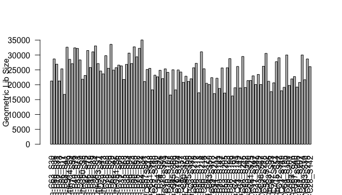

```r
Geo_Lib_Size <- colSums(log(counts+1))
barplot(Geo_Lib_Size, xlab="Cell", ylab="Geometric Lib Size", las=2)
```

```r
lcounts <- log(counts + 1)

# PC1 and Geometric library size correlation
pc1 = irlba(lcounts - rowMeans(lcounts), 1)$v[,1] ## partial SVD
cor(Geo_Lib_Size, pc1)
```

```
## [1] 0.9966524
```

## Run IA-SVA

Here, we run IA-SVA using Patient_ID and Geo_Lib_Size as known factors and identify five hidden factors. SVs are plotted in a pairwise fashion to uncover which SVs can seperate cell types.

```r
set.seed(454353)
Patient_ID <- anns$Patient_ID
mod <- model.matrix(~Patient_ID+Geo_Lib_Size)
iasva.res<- iasva(t(counts), mod[,-1],verbose=FALSE, permute=FALSE, num.sv=5) ##irlba
```

```
## IA-SVA running...
## SV1 Detected!
## SV2 Detected!
## SV3 Detected!
## SV4 Detected!
## SV5 Detected!
## # of significant surrogate variables: 5
```

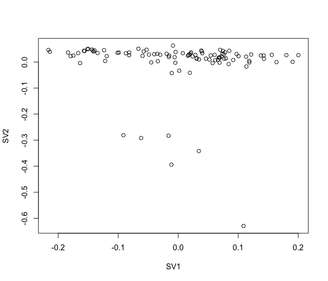

```r
iasva.sv <- iasva.res$sv

plot(iasva.sv[,1], iasva.sv[,2], xlab="SV1", ylab="SV2")
```

```r
Cell_Type <- as.factor(iasva.sv[,2] > -0.2)
levels(Cell_Type)=c("Cell1","Cell2")
table(Cell_Type)
```

```
## Cell_Type
## Cell1 Cell2
##     6    95
```

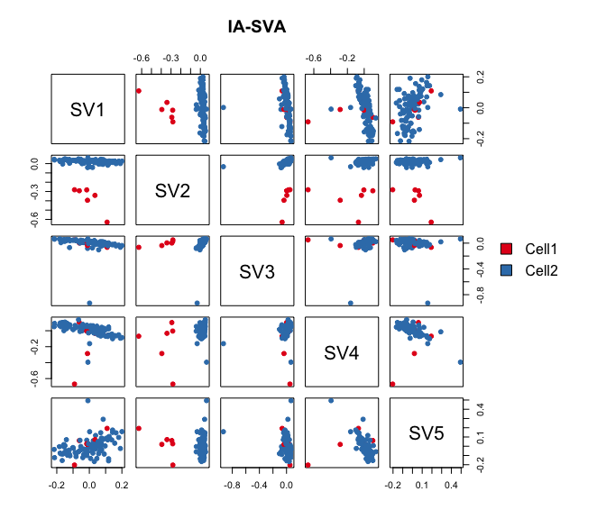

```r
# We identified 6 outlier cells based on SV2 that are marked in red
pairs(iasva.sv, main="IA-SVA", pch=21, col=color.vec[Cell_Type], bg=color.vec[Cell_Type], oma=c(4,4,6,12)) #4,4,6,12
legend("right", levels(Cell_Type), fill=color.vec, bty="n")
```

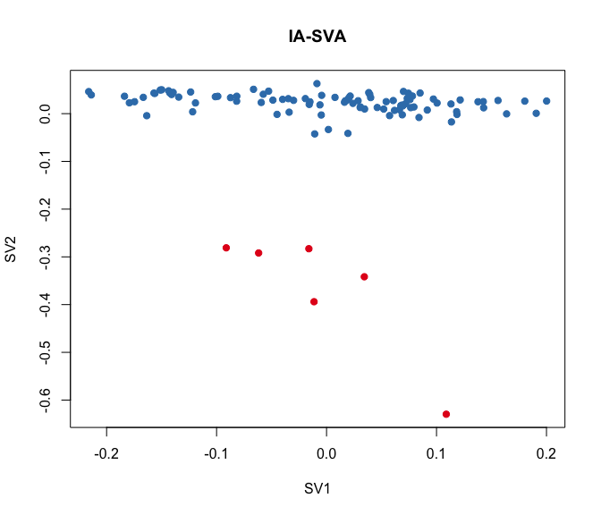

```r
plot(iasva.sv[,1:2], main="IA-SVA", pch=21, xlab="SV1", ylab="SV2", col=color.vec[Cell_Type], bg=color.vec[Cell_Type])
```

```r
cor(Geo_Lib_Size, iasva.sv[,2])
```

```
## [1] -0.1776038
```

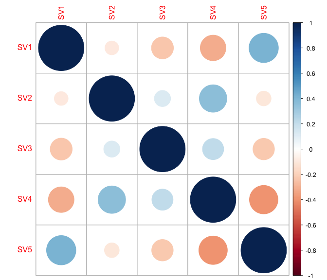

```r
corrplot(cor(iasva.sv))
```

## Find marker genes for the detected heterogeneity (SV2).

Here, using the find.markers() function we find marker genes (n=105 genes) that are significantly associated with SV2 (multiple testing adjusted p-value < 0.05, default significance cutoff, and R-squared value > 0.3, default R-squared cutoff).

```r
marker.counts <- find.markers(t(counts), as.matrix(iasva.sv[,2]))
```

```
## # of markers (): 105
## total # of unique markers:  105
```

```r
nrow(marker.counts)
```

```
## [1] 105
```

```r
rownames(marker.counts)
```

```
##   [1] "SMAD7"         "PMEPA1"        "FAM198B"       "ANGPTL2"
##   [5] "LINC00152"     "WIPF1"         "MYCT1"         "FLT1"
##   [9] "SYNM"          "MIR4435-1HG"   "RNF24"         "ENG"
##  [13] "RASSF2"        "NFIB"          "SLC1A5"        "SOX4"
##  [17] "ID3"           "ITGA5"         "TMEM233"       "FMNL2"
##  [21] "PXDN"          "PRDM1"         "C8orf4"        "ERG"
##  [25] "RFTN2"         "ZNF503"        "CLIC4"         "RP11-160E2.19"
##  [29] "DAB2"          "JAG1"          "LGALS9"        "ARHGAP31"
##  [33] "SNAI1"         "TIMP3"         "A2M"           "DCHS1"
##  [37] "PPAP2B"        "DPYSL3"        "UACA"          "THBS1"
##  [41] "HTRA1"         "MEF2C"         "SERPINB8"      "CHST3"
##  [45] "FSTL1"         "CLIC2"         "LGALS1"        "IL32"
##  [49] "S100A16"       "CD93"          "IGFBP4"        "RBMS1"
##  [53] "COL18A1"       "LAMA4"         "STC1"          "STAB1"
##  [57] "ACVRL1"        "ELTD1"         "COL4A1"        "LPHN2"
##  [61] "COL4A2"        "MSN"           "CTHRC1"        "ELK3"
##  [65] "EMP1"          "TINAGL1"       "TNFAIP2"       "P2RY6"
##  [69] "MCAM"          "C1QTNF5"       "MMP2"          "HBEGF"
##  [73] "SERPINE1"      "SPARC"         "SPARCL1"       "RAPGEF5"
##  [77] "ESAM"          "KDR"           "COL15A1"       "RASSF3"
##  [81] "REST"          "ITPRIPL2"      "ETS1"          "GMFG"
##  [85] "ANO7"          "GNG11"         "VWF"           "HDAC7"
##  [89] "CD9"           "IFITM2"        "IFITM3"        "PTRF"
##  [93] "CXCR4"         "SERPING1"      "PODXL"         "NES"
##  [97] "PLVAP"         "CALD1"         "LAMB2"         "IL4R"
## [101] "MMP1"          "IFI16"         "RHOJ"          "RBP5"
## [105] "ADAMTS4"
```

```r
anno.col <- data.frame(Cell_Type=Cell_Type)
rownames(anno.col) <- colnames(marker.counts)
head(anno.col)
```

```
##             Cell_Type
## 4th-C63_S30     Cell2
## 4th-C66_S36     Cell2
## 4th-C18_S31     Cell2
## 4th-C57_S18     Cell1
## 4th-C56_S17     Cell2
## 4th-C68_S41     Cell2
```

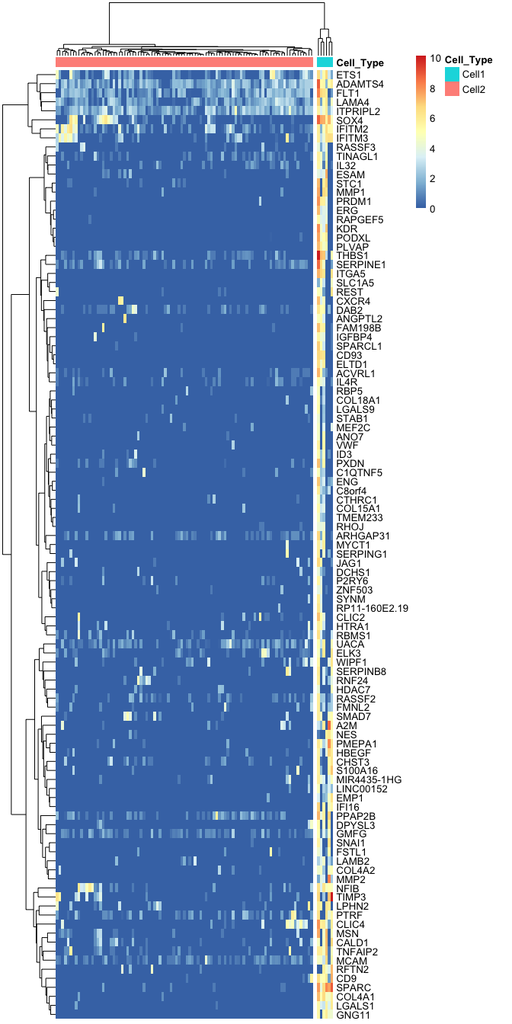

```r
pheatmap(log(marker.counts+1), show_colnames =FALSE, clustering_method = "ward.D2",cutree_cols = 2,annotation_col = anno.col)
```

## Run tSNE to detect the hidden heterogeneity.

For comparison purposes, we applied tSNE on read counts of all genes to identify the hidden heterogeneity. We used the Rtsne R package with default settings.

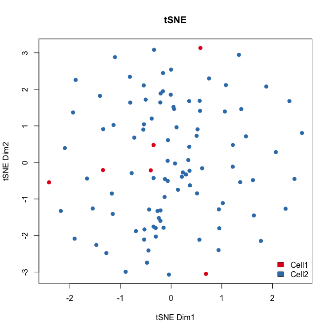

```r
set.seed(323542534)
tsne.res <- Rtsne(t(lcounts), dims = 2)

plot(tsne.res$Y, main="tSNE", xlab="tSNE Dim1", ylab="tSNE Dim2", pch=21, col=color.vec[Cell_Type], bg=color.vec[Cell_Type], oma=c(4,4,6,12))
legend("bottomright", levels(Cell_Type), fill=color.vec, bty="n")
```

As shown above, tSNE fails to detect the outlier cells that are identified by IA-SVA when all genes are used. Same color coding is used as above.

## Run tSNE post IA-SVA analyses, i.e., run tSNE on marker genes associated with SV2 as detected by IA-SVA.

Here, we apply tSNE on the marker genes for SV2 obtained from IA-SVA

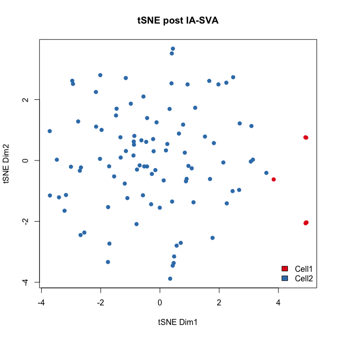

```r
set.seed(345233)
tsne.res <- Rtsne(unique(t(log(marker.counts+1))), dims = 2)

plot(tsne.res$Y, main="tSNE post IA-SVA", xlab="tSNE Dim1", ylab="tSNE Dim2", pch=21, col=color.vec[Cell_Type], bg=color.vec[Cell_Type], oma=c(4,4,6,12))
legend("bottomright", levels(Cell_Type), fill=color.vec, bty="n")
```

tSNE using SV2 marker genes better seperate these ourlier cells. This analyses suggest that gene selection using IA-SVA combined with tSNE analyses can be a powerful way to detect rare cells introducing variability in the single cell gene expression data.

## Run principal component analysis (PCA) to detect the hidden heterogeneity (SV2).

Here, we use PCA to detect the hidden heterogeneity (SV2) detected by IA-SVA.

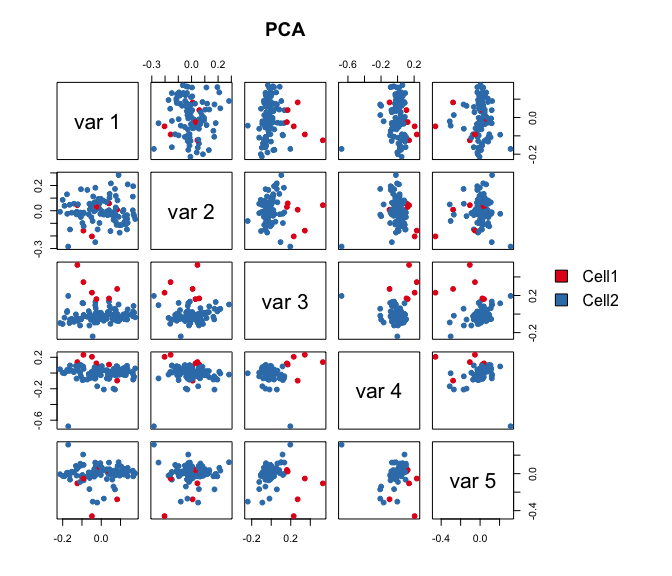

```r
pca.res = irlba(lcounts - rowMeans(lcounts), 5)$v ## partial SVD

pairs(pca.res, main="PCA", pch=21, col=color.vec[Cell_Type], bg=color.vec[Cell_Type], oma=c(4,4,6,12)) #4,4,6,12
legend("right", levels(Cell_Type), fill=color.vec, bty="n")
```

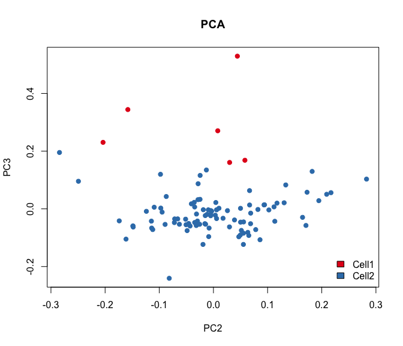

```r
plot(pca.res[,2:3], main="PCA", xlab="PC2", ylab="PC3", pch=21, col=color.vec[Cell_Type], bg=color.vec[Cell_Type], oma=c(4,4,6,12))
legend("bottomright", levels(Cell_Type), fill=color.vec, bty="n")
```

PC3 somewhat captures the six outlier cells, however this seperation is not as clear as the IA-SVA results.

## Run surrogate variable analysis (SVA) to detect the hidden heterogeneity (SV2).

```r
mod1 <- model.matrix(~Patient_ID+Geo_Lib_Size)
mod0 <- cbind(mod1[,1])

sva.res = svaseq(counts,mod1,mod0, n.sv=5)$sv
```

```
## Number of significant surrogate variables is:  5
## Iteration (out of 5 ):1  2  3  4  5
```

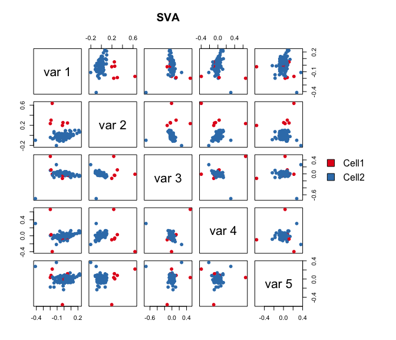

```r
pairs(sva.res, main="SVA", pch=21, col=color.vec[Cell_Type], bg=color.vec[Cell_Type], oma=c(4,4,6,12)) #4,4,6,12
legend("right", levels(Cell_Type), fill=color.vec, bty="n")
```

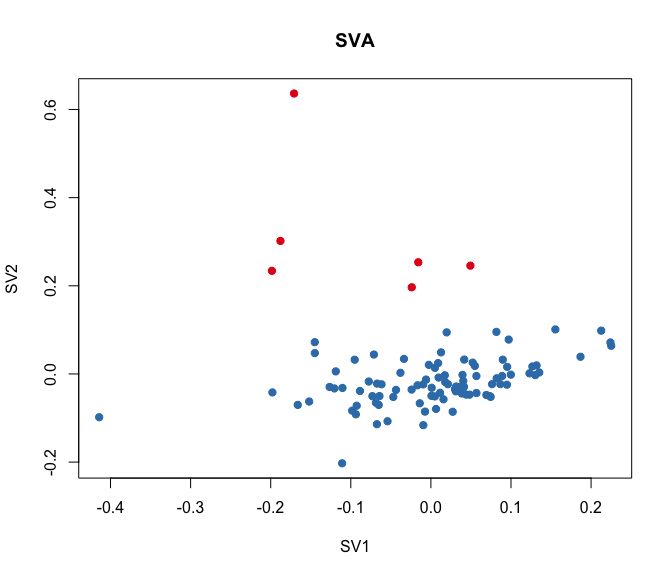

```r
plot(sva.res[,1:2], main="SVA", xlab="SV1", ylab="SV2", pch=21, col=color.vec[Cell_Type], bg=color.vec[Cell_Type])
```

SV2 is associated with the six outlier samples, however the seperation of these cells is not as clear as the IA-SVA results.

## Correlation between SV2 and the geometric library size

```r
cor(Geo_Lib_Size, iasva.sv[,2])
```

```
## [1] -0.1776038
```